# Index hopping

J. Ignacio Lucas Lledó

13/12/2021

We have now two batches of reads, because the sequencing center decided to run the machine a second time. Here I add the number of reads in the second batch to the table of sample features and I try to model the amount of index hopping among the index combinations where we can observe the misassignment of reads.

```bash
if [ ! -e TotalNumReads.txt ]; then
   FASTQDIR1='../../data/fastq'
   FASTQDIR2='../../data/fastr'
   if [ ! -e SampleIndexSeq.tsv ]; then cp ../2021-10-13/SampleIndexSeq.tsv ./; fi

   SAMPLE=( $(gawk '(NR > 1){gsub(/\"/,""); print $1}' SampleIndexSeq.tsv | sort) )
   THREADS=24
   for i in $(seq 0 $THREADS $(( ${#SAMPLE[@]} - 1 )) ); do
      for j in $(seq $i $(($i + $THREADS - 1)) ); do
         echo -e ${SAMPLE[$j]} "\t" \
            $(echo $(gunzip -c $FASTQDIR1/${SAMPLE[$j]}*_R1_001.fastq.gz 2> /dev/null | wc -l) "/4" | bc) "\t" \
            $(echo $(gunzip -c $FASTQDIR2/${SAMPLE[$j]}*_R1_001.fastq.gz 2> /dev/null | wc -l) "/4" | bc) \
            > $(printf "z_%s.txt" ${SAMPLE[$j]}) &
      done
      wait
   done
   for k in $(seq $(( $j + 1)) $(( ${#SAMPLE[@]} - 1)) ); do
      echo -e ${SAMPLE[$k]} "\t" \
         $(echo $(gunzip -c $FASTQDIR1/${SAMPLE[$k]}*_R1_001.fastq.gz 2> /dev/null | wc -l) "/4" | bc) "\t" \
         $(echo $(gunzip -c $FASTQDIR2/${SAMPLE[$k]}*_R1_001.fastq.gz 2> /dev/null | wc -l) "/4" | bc) \
         > $(printf "z_%s.txt" ${SAMPLE[$k]}) &
   done
   wait
   cat z_*.txt | sort -k 1,1 > TotalNumReads.txt
   rm z*
fi

if [ ! -e Features.RData ]; then
   cp ../2021-11-23/Features.RData ./
fi
```

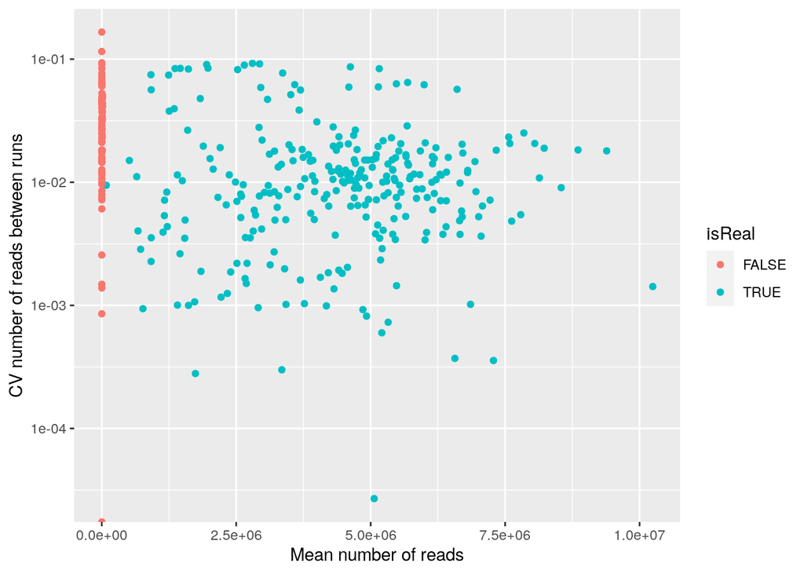

```r
library('ggplot2')
load('Features.RData')
TotalNumReads <- read.table('TotalNumReads.txt',
                            col.names = c('Sample','numReads1', 'numReads2'),
                            row.names = 1)
Features$numReads1 <- TotalNumReads[row.names(Features), 'numReads1']
Features$numReads2 <- TotalNumReads[row.names(Features), 'numReads2']
Features$meanNumReads <- (Features$numReads1 + Features$numReads2) / 2
# Coefficient of variation between the two runs: CV(x)=sd(x)/mean(x).
# A downwardly biased estimation of sd of two numbers: abs(x - y)/sqrt(2)
Features$CVnumReads <- abs(Features$numReads1 - Features$numReads2) / (sqrt(2) * Features$meanNumReads)
stopifnot(all.equal(Features$numReads, Features$numReads1))
Features <- Features[, -(which(names(Features) == 'numReads'))]

f <- Features$i7 != 'N729'
ggplot(Features[f,], aes(x = meanNumReads, y = CVnumReads, color = isReal)) +
  geom_point() + scale_y_log10() + ylab('CV number of reads between runs') +
  xlab('Mean number of reads')
```

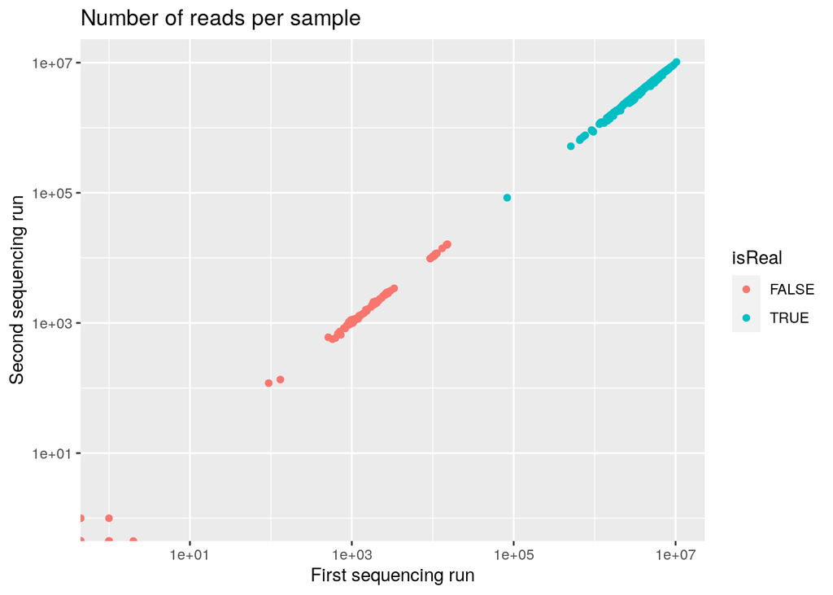

```r
ggplot(data = Features, mapping = aes(x = numReads1, y = numReads2, color = isReal)) +
  geom_point() + scale_y_log10() + scale_x_log10() +
  xlab('First sequencing run') + ylab('Second sequencing run') + ggtitle('Number of reads per sample')
```

The sequencing run does not affect much the number of reads. Even the amount of index hopping is the same between technical replicates of the sequencing.

## Determinants of index hopping

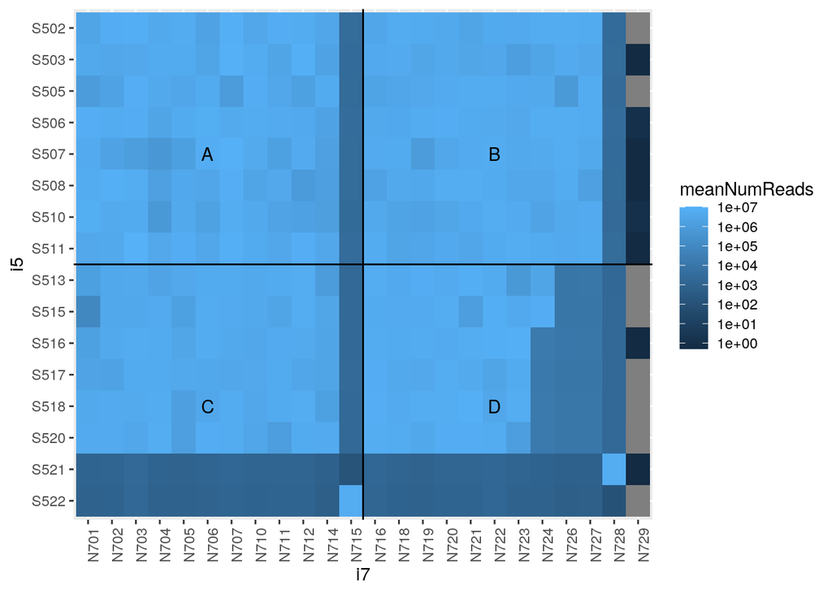

```r
ggplot(data = Features,
       mapping = aes(x = i7, y = i5, fill = meanNumReads)) +
   geom_tile() + geom_hline(yintercept = 8.5) + geom_vline(xintercept = 12.5) +
   scale_fill_gradient(trans = 'log',
                       breaks = c(1,10,100,1000,10000,100000,1000000,10000000)) +
   theme(axis.text.x = element_text(angle = 90)) +
   scale_y_discrete(limits = rev) +
   annotate(geom = 'text', x = c(6,18,6,18), y=c(12,12,4,4), label=c('A','B','C','D'))
```

There are different kinds of samples, in terms of their expected amount of index hopping:

1. 278 real samples identified with i5 and i7 indices that are both shared with other real samples.
2. Two real samples identified with i5 and i7 indices not shared with any other sample.
3. And mock samples all the reads of which come from index hopping.

Among the mock samples, those with i7 index N729 stick out for having extremely low numbers of reads: zero or one. This is the only index that was not used at all. Because its tube was never opened, molecules with this index must have been absent in the pool. The few reads reporting N729 can only come from technical artifacts, such as errors in reading the index sequence. Thus, most of the index hopping must be due not to sequencing errors, but to real molecules.

The presence of free adapters is supposed to be the main cause of index hopping. After having cleaned up the pools and after size selection, the amount of free adapters in the pool must have been negligible. Fragmentation of the DNA fragments in the libraries can also produce free adapters, and this is the reason why they recommend libraries to be stored at -20 C.

In any case, the number of reads missassigned to an index must be proportional to the number of fragments in the pool actually labeled with that index. This is quite apparent in the figure above, but can be made more explicit. Furthermore I wonder if missassignment to an erroneous i5 is just as probable as missassignment to an erroneous i7.

```r
# Number of real samples sharing one or the other index (excluding itself, if real):
Features$i5neiNum <- sapply(1:384, function(x){
  sum(Features$isReal & Features$i5 == Features[x, 'i5'])
}) - Features$isReal
Features$i7neiNum <- sapply(1:384, function(x){
  sum(Features$isReal & Features$i7 == Features[x, 'i7'])
}) - Features$isReal
Features$neiNum     <- Features$i5neiNum + Features$i7neiNum
Features$neiNumProd <- Features$i5neiNum * Features$i7neiNum

f <- ! Features$isReal & Features$i7 != 'N729'
summary(lm(meanNumReads ~ neiNum, data = Features[f, ]))
```

```
##
## Call:
## lm(formula = meanNumReads ~ neiNum, data = Features[f, ])
##
## Residuals:
##     Min      1Q  Median      3Q     Max
## -3361.5 -1795.9  -421.1  1711.5  6725.5
##
## Coefficients:
##             Estimate Std. Error t value Pr(>|t|)
## (Intercept) -7185.44     903.72  -7.951 6.65e-12 ***
## neiNum        577.84      47.12  12.262  < 2e-16 ***
## ---
## Signif. codes:  0 '***' 0.001 '**' 0.01 '*' 0.05 '.' 0.1 ' ' 1
##
## Residual standard error: 2477 on 86 degrees of freedom
## Multiple R-squared:  0.6362, Adjusted R-squared:  0.6319
## F-statistic: 150.4 on 1 and 86 DF,  p-value: < 2.2e-16
```

```r
summary(lm(meanNumReads ~ i5neiNum + i7neiNum, data = Features[f,]))
```

```
##
## Call:
## lm(formula = meanNumReads ~ i5neiNum + i7neiNum, data = Features[f,
##     ])
##
## Residuals:
##     Min      1Q  Median      3Q     Max
## -2439.8 -1372.2  -986.2  1359.2  8133.9
##
## Coefficients:
##             Estimate Std. Error t value Pr(>|t|)
## (Intercept) -9416.12    1095.16  -8.598 3.52e-13 ***
## i5neiNum      630.31      47.47  13.279  < 2e-16 ***
## i7neiNum      784.89      77.49  10.128 2.83e-16 ***
## ---
## Signif. codes:  0 '***' 0.001 '**' 0.01 '*' 0.05 '.' 0.1 ' ' 1
##
## Residual standard error: 2349 on 85 degrees of freedom
## Multiple R-squared:  0.6768, Adjusted R-squared:  0.6692
## F-statistic:    89 on 2 and 85 DF,  p-value: < 2.2e-16
```

```r
summary(lm(meanNumReads ~ i5neiNum * i7neiNum, data = Features[f,]))
```

```
##
## Call:
## lm(formula = meanNumReads ~ i5neiNum * i7neiNum, data = Features[f,
##     ])
##
## Residuals:
##      Min       1Q   Median       3Q      Max
## -1452.33  -206.40    -5.21   192.36  2182.20
##
## Coefficients:
##                   Estimate Std. Error t value Pr(>|t|)
## (Intercept)       -148.358    371.141  -0.400  0.69037
## i5neiNum            55.601     19.668   2.827  0.00587 **
## i7neiNum            20.097     28.409   0.707  0.48126
## i5neiNum:i7neiNum   69.355      1.909  36.323  < 2e-16 ***
## ---
## Signif. codes:  0 '***' 0.001 '**' 0.01 '*' 0.05 '.' 0.1 ' ' 1
##
## Residual standard error: 578 on 84 degrees of freedom
## Multiple R-squared:  0.9807, Adjusted R-squared:   0.98
## F-statistic:  1419 on 3 and 84 DF,  p-value: < 2.2e-16
```

```r
summary(lm(meanNumReads ~ neiNumProd, data = Features[f,]))
```

```
##
## Call:
## lm(formula = meanNumReads ~ neiNumProd, data = Features[f, ])
##
## Residuals:
##      Min       1Q   Median       3Q      Max
## -1470.13  -393.27   -64.77   324.33  2047.24
##
## Coefficients:
##             Estimate Std. Error t value Pr(>|t|)
## (Intercept)  401.604     89.647    4.48 2.29e-05 ***
## neiNumProd    73.726      1.319   55.90  < 2e-16 ***
## ---
## Signif. codes:  0 '***' 0.001 '**' 0.01 '*' 0.05 '.' 0.1 ' ' 1
##
## Residual standard error: 672.2 on 86 degrees of freedom
## Multiple R-squared:  0.9732, Adjusted R-squared:  0.9729
## F-statistic:  3124 on 1 and 86 DF,  p-value: < 2.2e-16
```

```r
# Number of real samples sharing one index or the other and in the same plate.
Features$i5neiNumPlate <- sapply(1:384, function(x){
  sum(Features$isReal &
        Features$i5 == Features[x, 'i5'] &
        Features$plate == Features[x, 'plate'])
}) - Features$isReal
Features$i7neiNumPlate <- sapply(1:384, function(x){
  sum(Features$isReal &
        Features$i7 == Features[x, 'i7'] &
        Features$plate == Features[x, 'plate'])
}) - Features$isReal
Features$neiNumPlate     <- Features$i5neiNumPlate + Features$i7neiNumPlate
Features$neiNumPlateProd <- Features$i5neiNumPlate * Features$i7neiNumPlate

f <- ! Features$isReal & Features$i7 != 'N729'
summary(lm(meanNumReads ~ neiNumPlate, data = Features[f,]))
```

```
##
## Call:
## lm(formula = meanNumReads ~ neiNumPlate, data = Features[f, ])
##
## Residuals:
##    Min     1Q Median     3Q    Max
##  -2824  -2076  -1705  -1095  11838
##
## Coefficients:
##             Estimate Std. Error t value Pr(>|t|)
## (Intercept)   1132.3     1240.6   0.913   0.3640
## neiNumPlate    305.4      156.0   1.958   0.0534 .
## ---
## Signif. codes:  0 '***' 0.001 '**' 0.01 '*' 0.05 '.' 0.1 ' ' 1
##
## Residual standard error: 4018 on 86 degrees of freedom
## Multiple R-squared:  0.0427, Adjusted R-squared:  0.03157
## F-statistic: 3.836 on 1 and 86 DF,  p-value: 0.05341
```

```r
summary(lm(meanNumReads ~ i5neiNumPlate + i7neiNumPlate, data = Features[f,]))
```

```
##
## Call:
## lm(formula = meanNumReads ~ i5neiNumPlate + i7neiNumPlate, data = Features[f,
##     ])
##
## Residuals:
##     Min      1Q  Median      3Q     Max
## -3581.3 -2737.1  -391.5   137.0 11659.5
##
## Coefficients:
##               Estimate Std. Error t value Pr(>|t|)
## (Intercept)     4136.8     1363.7   3.034  0.00321 **
## i5neiNumPlate    126.0      150.4   0.838  0.40444
## i7neiNumPlate   -479.4      241.6  -1.984  0.05048 .
## ---
## Signif. codes:  0 '***' 0.001 '**' 0.01 '*' 0.05 '.' 0.1 ' ' 1
##
## Residual standard error: 3702 on 85 degrees of freedom
## Multiple R-squared:  0.1969, Adjusted R-squared:  0.178
## F-statistic: 10.42 on 2 and 85 DF,  p-value: 8.974e-05
```

```r
summary(lm(meanNumReads ~ i5neiNumPlate * i7neiNumPlate, data = Features[f,]))
```

```
##
## Call:
## lm(formula = meanNumReads ~ i5neiNumPlate * i7neiNumPlate, data = Features[f,
##     ])
##
## Residuals:
##     Min      1Q  Median      3Q     Max
## -4171.0 -2283.1  -756.2   607.3  9638.3
##
## Coefficients:
##                             Estimate Std. Error t value Pr(>|t|)
## (Intercept)                 4693.383   1368.464   3.430 0.000939 ***
## i5neiNumPlate                 -5.476    161.664  -0.034 0.973057
## i7neiNumPlate               -683.947    258.413  -2.647 0.009703 **
## i5neiNumPlate:i7neiNumPlate  199.574     99.474   2.006 0.048042 *
## ---
## Signif. codes:  0 '***' 0.001 '**' 0.01 '*' 0.05 '.' 0.1 ' ' 1
##
## Residual standard error: 3638 on 84 degrees of freedom
## Multiple R-squared:  0.2336, Adjusted R-squared:  0.2062
## F-statistic: 8.535 on 3 and 84 DF,  p-value: 5.185e-05
```

```r
summary(lm(meanNumReads ~ neiNumPlateProd, data = Features[f,]))
```

```
##
## Call:
## lm(formula = meanNumReads ~ neiNumPlateProd, data = Features[f,
##     ])
##
## Residuals:
##     Min      1Q  Median      3Q     Max
## -3272.2 -2415.8 -1880.6  -172.1 10675.3
##
## Coefficients:
##                 Estimate Std. Error t value Pr(>|t|)
## (Intercept)       2941.6      535.4   5.494 3.94e-07 ***
## neiNumPlateProd    150.2      100.7   1.491     0.14
## ---
## Signif. codes:  0 '***' 0.001 '**' 0.01 '*' 0.05 '.' 0.1 ' ' 1
##
## Residual standard error: 4055 on 86 degrees of freedom
## Multiple R-squared:  0.0252, Adjusted R-squared:  0.01386
## F-statistic: 2.223 on 1 and 86 DF,  p-value: 0.1396
```

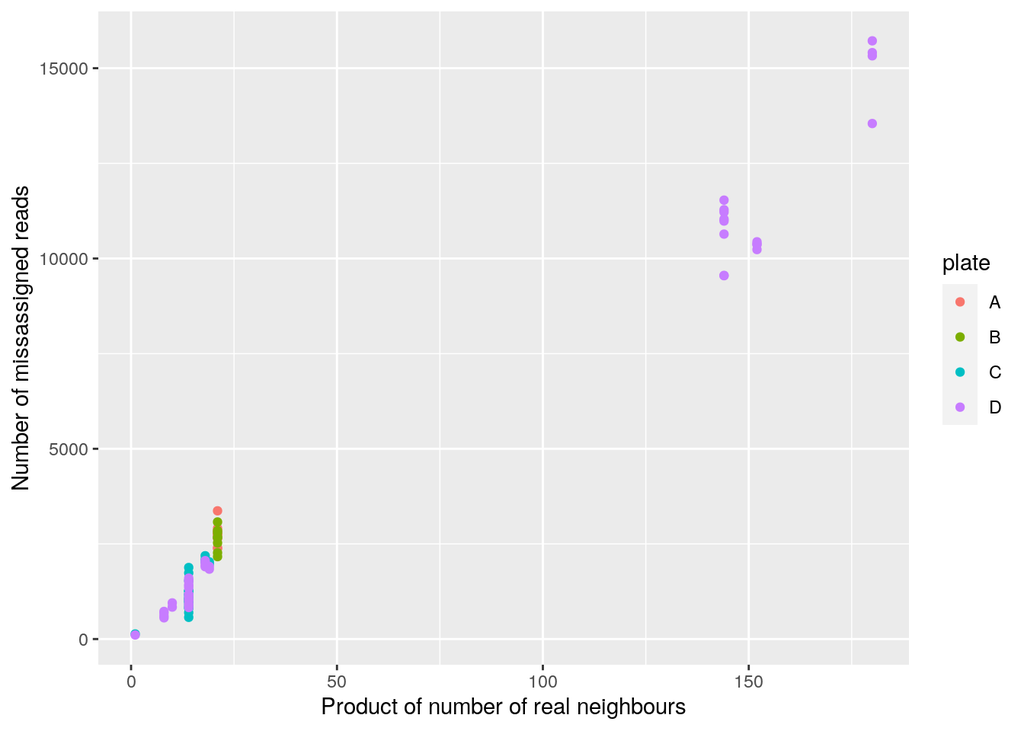

```r
ggplot(data = Features[f,], mapping = aes(x = neiNumProd, y = meanNumReads, color = plate)) +
  geom_point() + xlab('Product of number of real neighbours') + ylab('Number of missassigned reads')
```

It is not the number of real samples *in the same plate*, but the product or interaction between the number of real samples sharing one index and the number sharing the other *in the whole experiment* what determines better the amount of index hopping.

```r
# Number of reads with same index i5 or i7
Features$i5neiReads <- sapply(1:384, function(x) {
  sum(Features[Features$isReal & Features$i5 == Features[x,'i5'], 'meanNumReads'])
}) - Features$isReal * Features$meanNumReads
Features$i7neiReads <- sapply(1:384, function(x) {
  sum(Features[Features$isReal & Features$i7 == Features[x,'i7'], 'meanNumReads'])
}) - Features$isReal * Features$meanNumReads
Features$neiReads     <- Features$i5neiReads + Features$i7neiReads
Features$neiReadsProd <- Features$i5neiReads * Features$i7neiReads

f <- ! Features$isReal & Features$i7 != 'N729'
summary(lm(meanNumReads ~ neiReads, data = Features[f,]))
```

```
##
## Call:
## lm(formula = meanNumReads ~ neiReads, data = Features[f, ])
##
## Residuals:
##     Min      1Q  Median      3Q     Max
## -4187.1 -1756.2  -484.5  1997.6  6665.2
##
## Coefficients:
##               Estimate Std. Error t value Pr(>|t|)
## (Intercept) -6.616e+03  8.908e+02  -7.427  7.5e-11 ***
## neiReads     1.223e-04  1.035e-05  11.816  < 2e-16 ***
## ---
## Signif. codes:  0 '***' 0.001 '**' 0.01 '*' 0.05 '.' 0.1 ' ' 1
##
## Residual standard error: 2536 on 86 degrees of freedom
## Multiple R-squared:  0.6188, Adjusted R-squared:  0.6144
## F-statistic: 139.6 on 1 and 86 DF,  p-value: < 2.2e-16
```

```r
summary(lm(meanNumReads ~ i5neiReads + i7neiReads, data = Features[f,]))
```

```
##
## Call:
## lm(formula = meanNumReads ~ i5neiReads + i7neiReads, data = Features[f,
##     ])
##
## Residuals:
##     Min      1Q  Median      3Q     Max
## -3938.8 -1549.7  -689.9  2073.7  6333.2
##
## Coefficients:
##               Estimate Std. Error t value Pr(>|t|)
## (Intercept) -7.708e+03  1.067e+03  -7.225 2.00e-10 ***
## i5neiReads   1.267e-04  1.050e-05  12.064  < 2e-16 ***
## i7neiReads   1.468e-04  1.696e-05   8.655 2.69e-13 ***
## ---
## Signif. codes:  0 '***' 0.001 '**' 0.01 '*' 0.05 '.' 0.1 ' ' 1
##
## Residual standard error: 2503 on 85 degrees of freedom
## Multiple R-squared:  0.6329, Adjusted R-squared:  0.6243
## F-statistic: 73.28 on 2 and 85 DF,  p-value: < 2.2e-16
```

```r
summary(lm(meanNumReads ~ i5neiReads * i7neiReads, data = Features[f,]))
```

```
##
## Call:
## lm(formula = meanNumReads ~ i5neiReads * i7neiReads, data = Features[f,
##     ])
##
## Residuals:
##      Min       1Q   Median       3Q      Max
## -1745.45  -178.19    12.04   160.80  1929.84
##
## Coefficients:
##                         Estimate Std. Error t value Pr(>|t|)
## (Intercept)           -9.974e+01  2.531e+02  -0.394   0.6945
## i5neiReads             5.989e-06  3.162e-06   1.894   0.0617 .
## i7neiReads            -2.572e-06  4.408e-06  -0.583   0.5612
## i5neiReads:i7neiReads  3.696e-12  7.604e-14  48.606   <2e-16 ***
## ---
## Signif. codes:  0 '***' 0.001 '**' 0.01 '*' 0.05 '.' 0.1 ' ' 1
##
## Residual standard error: 466.5 on 84 degrees of freedom
## Multiple R-squared:  0.9874, Adjusted R-squared:  0.9869
## F-statistic:  2194 on 3 and 84 DF,  p-value: < 2.2e-16
```

```r
summary(lm(meanNumReads ~ neiReadsProd, data = Features[f,]))
```

```
##
## Call:
## lm(formula = meanNumReads ~ neiReadsProd, data = Features[f,
##     ])
##
## Residuals:
##      Min       1Q   Median       3Q      Max
## -1764.98  -297.07   -95.28   211.56  1825.50
##
## Coefficients:
##                Estimate Std. Error t value Pr(>|t|)
## (Intercept)  -2.428e+01  7.470e+01  -0.325    0.746
## neiReadsProd  3.811e-12  5.377e-14  70.863   <2e-16 ***
## ---
## Signif. codes:  0 '***' 0.001 '**' 0.01 '*' 0.05 '.' 0.1 ' ' 1
##
## Residual standard error: 532.9 on 86 degrees of freedom
## Multiple R-squared:  0.9832, Adjusted R-squared:  0.983
## F-statistic:  5022 on 1 and 86 DF,  p-value: < 2.2e-16
```

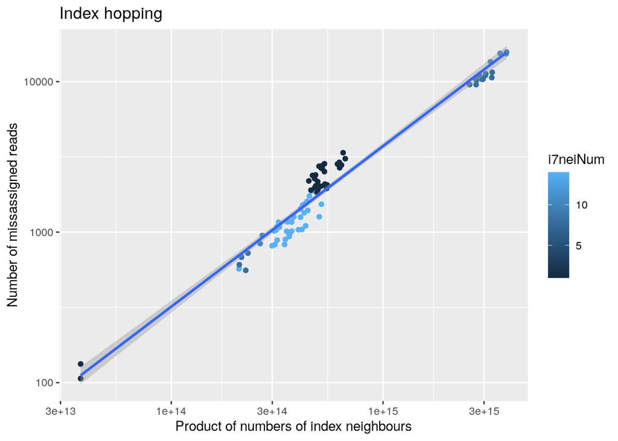

```r
ggplot(data = Features[f,], mapping = aes(x = neiReadsProd, y = meanNumReads, color = i7neiNum)) +
  geom_point() + geom_smooth(method = 'lm') + scale_y_log10() + scale_x_log10() +
  xlab('Product of numbers of index neighbours') + ylab('Number of missassigned reads') +
  ggtitle('Index hopping')
```

## Conclusions

I have modelled the number of reads in non real samples. That is, the number of misassigned reads where we can count them. I expected misassignments to be due to independent events involving a misreading of either index i5 or index i7. However, the sum of *i5-neighbours* and *i7-neighbours* is not as predictive of the amount of misassignment as their product. This points at an interaction between the number of samples (or reads) sharing the i5 and the number sharing the i7 indices. If I understand well, this means that errors do not only come from misreading one of the two indices, but often from misreading both.

It is also notable that the cross-contamination is not limited to the plate, but affects the whole pool together. This suggests that the problem is **not** an erroneous manipulation of the indices during library preparation, but something that happens after pooling all samples together.

## Prediction of misassigned reads in real samples

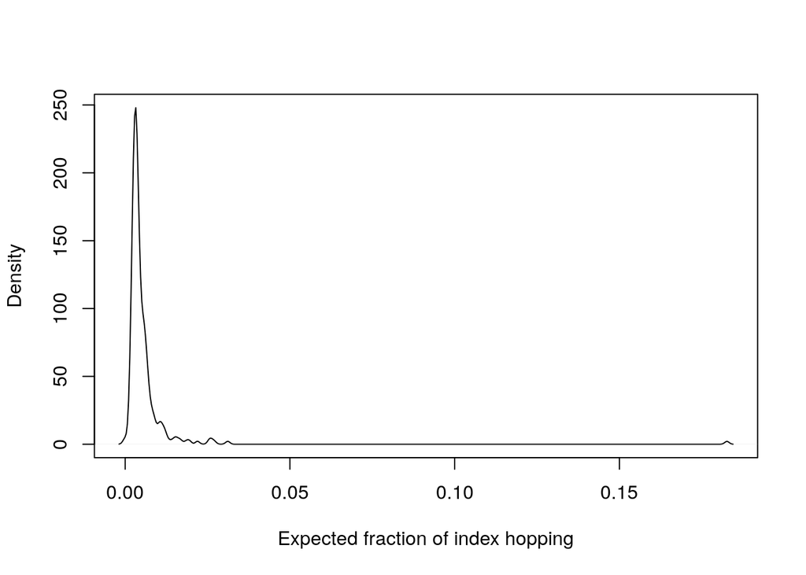

```r
f <- ! Features$isReal & Features$i7 != 'N729'
M0 <- lm(meanNumReads ~ i5neiReads * i7neiReads, data = Features[f,])
Predicted <- predict(M0, Features[Features$isReal, c('i5neiReads', 'i7neiReads')], se.fit = TRUE)
plot(density(Predicted$fit / Features[names(Predicted$fit), 'meanNumReads']),
     xlab = 'Expected fraction of index hopping', main = '')
```

The only sample where we expect a proportion of wrongly assigned reads is the one with fewest reads: SUO095, which looked ok in the electrophoresis but turned out with only 167111 reads between the two sequencing runs.